# Alcohol Consumption and Grades

CARTUS YOU

2018年7月27日

## **PART I Purpose**

Examines whether **alcohol consumption** has any predictive power over student **average grades**.

#### **Preparation**

- Set the working direction and import data.
- Merge the data by columns but **not including which related to grdes**, since we don’t know whether the alcohol consumption have different influences between math and portugueses grades yet.

```r
setwd("D:/2018.07 R_DataAnalysis/2018SUMMER_R/data")

ptgs.course <- read.csv("student-por.csv")
math.course <- read.csv("student-mat.csv")

data.source <- merge(ptgs.course,math.course,by=c("school","sex","age","address","famsize","Pstatus",
                                                  "Medu","Fedu","Mjob","Fjob","reason","nursery","internet",
                                                  "guardian","guardian","traveltime","studytime","failures",
                                                  "schoolsup","famsup","activities","higher","romantic",
                                                  "famrel","freetime","goout","Dalc","Walc","health","absences"))
head(data.source)
```

```
##   school sex age address famsize Pstatus Medu Fedu     Mjob     Fjob
## 1     GP   F  15       R     GT3       T    2    2  at_home    other
## 2     GP   F  15       R     GT3       T    2    4 services   health
## 3     GP   F  15       R     GT3       T    3    4 services   health
## 4     GP   F  15       U     GT3       A    3    3    other   health
## 5     GP   F  15       U     GT3       A    4    3 services services
## 6     GP   F  15       U     GT3       T    1    1    other    other
##       reason nursery internet guardian traveltime studytime failures
## 1 reputation     yes       no   mother          1         1        0
## 2     course     yes      yes   mother          1         3        0
## 3     course     yes      yes   mother          1         3        0
## 4 reputation     yes       no   father          1         4        0
## 5 reputation     yes      yes   mother          1         2        0
## 6       home      no      yes   father          1         2        0
##   schoolsup famsup activities higher romantic famrel freetime goout Dalc
## 1       yes    yes        yes    yes       no      4        3     1    1
## 2       yes    yes        yes    yes       no      4        3     2    1
## 3       yes    yes        yes    yes       no      4        3     2    1
## 4       yes     no         no    yes       no      4        3     3    1
## 5        no    yes        yes    yes       no      4        3     2    1
## 6        no    yes        yes    yes       no      4        3     2    2
##   Walc health absences paid.x G1.x G2.x G3.x paid.y G1.y G2.y G3.y
## 1    1      2        8     no   14   13   12    yes   14   13   13
## 2    1      5        2     no   10   11   10    yes   10    9    8
## 3    1      5        2     no   11   12   12    yes   12   12   11
## 4    1      4       10     no   10   10   10     no   10   11   11
## 5    1      1        0     no   15   14   15    yes   14   15   15
## 6    3      4        2     no   13   12   12     no    9   10   10
```

```r
summary(data.source)
```

```
##  school  sex         age        address famsize  Pstatus      Medu
##  GP:73   F:50   Min.   :15.00   R:17    GT3:61   A: 7    Min.   :0.0
##  MS:12   M:35   1st Qu.:15.00   U:68    LE3:24   T:78    1st Qu.:2.0
##                 Median :16.00                            Median :3.0
##                 Mean   :16.39                            Mean   :2.8
##                 3rd Qu.:17.00                            3rd Qu.:4.0
##                 Max.   :19.00                            Max.   :4.0
##       Fedu             Mjob          Fjob           reason   nursery
##  Min.   :1.000   at_home :11   at_home : 5   course    :32   no :18
##  1st Qu.:2.000   health  : 8   health  : 7   home      :25   yes:67
##  Median :3.000   other   :35   other   :41   other     : 6
##  Mean   :2.647   services:16   services:24   reputation:22
##  3rd Qu.:4.000   teacher :15   teacher : 8
##  Max.   :4.000
##  internet   guardian    traveltime      studytime        failures
##  no :13   father:24   Min.   :1.000   Min.   :1.000   Min.   :0.00000
##  yes:72   mother:57   1st Qu.:1.000   1st Qu.:2.000   1st Qu.:0.00000
##           other : 4   Median :1.000   Median :2.000   Median :0.00000
##                       Mean   :1.353   Mean   :2.106   Mean   :0.09412
##                       3rd Qu.:2.000   3rd Qu.:3.000   3rd Qu.:0.00000
##                       Max.   :3.000   Max.   :4.000   Max.   :3.00000
##  schoolsup famsup   activities higher   romantic     famrel
##  no :73    no :33   no :46     no : 1   no :57   Min.   :2.000
##  yes:12    yes:52   yes:39     yes:84   yes:28   1st Qu.:4.000
##                                                  Median :4.000
##                                                  Mean   :4.176
##                                                  3rd Qu.:5.000
##                                                  Max.   :5.000
##     freetime         goout            Dalc            Walc
##  Min.   :1.000   Min.   :1.000   Min.   :1.000   Min.   :1.000
##  1st Qu.:3.000   1st Qu.:2.000   1st Qu.:1.000   1st Qu.:1.000
##  Median :3.000   Median :3.000   Median :1.000   Median :2.000
##  Mean   :3.212   Mean   :2.812   Mean   :1.282   Mean   :1.976
##  3rd Qu.:4.000   3rd Qu.:4.000   3rd Qu.:1.000   3rd Qu.:3.000
##  Max.   :5.000   Max.   :5.000   Max.   :3.000   Max.   :5.000
##      health         absences      paid.x        G1.x            G2.x
##  Min.   :1.000   Min.   : 0.000   no :81   Min.   : 5.00   Min.   : 8.00
##  1st Qu.:3.000   1st Qu.: 0.000   yes: 4   1st Qu.:11.00   1st Qu.:11.00
##  Median :4.000   Median : 0.000            Median :13.00   Median :12.00
##  Mean   :3.506   Mean   : 1.894            Mean   :12.75   Mean   :12.82
##  3rd Qu.:5.000   3rd Qu.: 2.000            3rd Qu.:14.00   3rd Qu.:14.00
##  Max.   :5.000   Max.   :14.000            Max.   :19.00   Max.   :18.00
##       G3.x       paid.y        G1.y            G2.y            G3.y
##  Min.   : 0.00   no :39   Min.   : 6.00   Min.   : 5.00   Min.   : 0
##  1st Qu.:11.00   yes:46   1st Qu.: 9.00   1st Qu.:10.00   1st Qu.:10
##  Median :13.00            Median :12.00   Median :12.00   Median :12
##  Mean   :13.21            Mean   :12.08   Mean   :12.24   Mean   :12
##  3rd Qu.:15.00            3rd Qu.:14.00   3rd Qu.:15.00   3rd Qu.:15
##  Max.   :19.00            Max.   :19.00   Max.   :19.00   Max.   :19
```

#### **Plot**

- Plot a sacatter to see the relationships bwtween alcohol consumption and grades.
- The two scatter plots have few implications:
1. Among the 85 students, **no one consumed high or very high levels of alcohol on workday basis**.
2. Almost all of those **who earned relatively high scores consumed very low levels of alcohol on weekend basis**.
3. Math and Portuguese grades seem to **correlate highly** with each other.

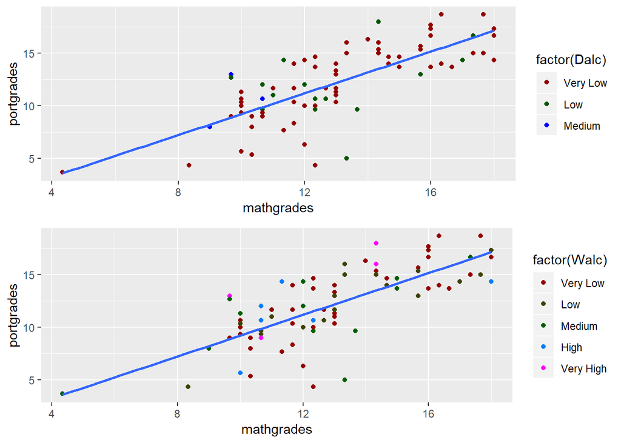

```r
library(ggplot2)
str1=ggplot(data.source, aes(x=mathgrades, y=portgrades)) +
  geom_point(aes(colour=factor(Dalc)))+ scale_colour_hue(l=25,c=150)+
  geom_smooth(method = "lm", se = FALSE)
str2=ggplot(data.source, aes(x=mathgrades, y=portgrades))+
  geom_point(aes(colour=factor(Walc)))+ scale_colour_hue(l=25,c=150)+
  geom_smooth(method = "lm", se = FALSE)
library(gridExtra)
grid.arrange(str1,str2,nrow=2)
```

- By the implication 3, I think that **it’s acceptable to combine the two grades together** without worrying the lost of features.
- To be cautious, I still calculated the adjusted R squared to make sure it works.
- The R squared is about 0.55, which means that the correlation coefficient between math and Portuguese grades is **about 0.74 and that about 55% of the variation** in Portuguese grades can be explained by the variation in math grades.

```r
reg1 <- lm(mathgrades ~ portgrades, data=data.source)
print(summary(reg1)$r.squared)
```

```
## [1] 0.5539108
```

```r
print(sqrt(summary(reg1)$r.squared))
```

```
## [1] 0.7442518
```

#### **Create New Dataframe**

- Combine the original data by rows.
- Create a new column(alcohol) to separate the students into two groups:**having alcoholic consumption, and not.**

```r
library(dplyr)
```

```r
new.source <-rbind(math.course, ptgs.course) #combine the two datasets
# and eliminate the repeats:
apply.source <- new.source %>% distinct(school,sex,age,address,famsize,Pstatus,Medu,Fedu,Mjob,Fjob,reason,
                                        guardian,traveltime,studytime,failures,schoolsup,
                                        famsup,activities,nursery,higher,internet,romantic,
                                        famrel,freetime,goout,Dalc,Walc,health,absences, .keep_all = TRUE)
apply.source$avggrades <- rowMeans(cbind(apply.source$G1,apply.source$G2,apply.source$G3))
apply.source$alcohol <- apply.source$Dalc + apply.source$Walc
apply.source$alcohol <- as.factor(apply.source$alcohol)
apply.source$alc <- mapvalues(apply.source$alcohol,
                              from = 2:10,
                              to = c("no","yes","yes","yes","yes","yes","yes","yes","yes"))
head(apply.source)
```

```
##   school sex age address famsize Pstatus Medu Fedu     Mjob     Fjob
## 1     GP   F  18       U     GT3       A    4    4  at_home  teacher
## 2     GP   F  17       U     GT3       T    1    1  at_home    other
## 3     GP   F  15       U     LE3       T    1    1  at_home    other
## 4     GP   F  15       U     GT3       T    4    2   health services
## 5     GP   F  16       U     GT3       T    3    3    other    other
## 6     GP   M  16       U     LE3       T    4    3 services    other
##       reason guardian traveltime studytime failures schoolsup famsup paid
## 1     course   mother          2         2        0       yes     no   no
## 2     course   father          1         2        0        no    yes   no
## 3      other   mother          1         2        3       yes     no  yes
## 4       home   mother          1         3        0        no    yes  yes
## 5       home   father          1         2        0        no    yes  yes
## 6 reputation   mother          1         2        0        no    yes  yes
##   activities nursery higher internet romantic famrel freetime goout Dalc
## 1         no     yes    yes       no       no      4        3     4    1
## 2         no      no    yes      yes       no      5        3     3    1
## 3         no     yes    yes      yes       no      4        3     2    2
## 4        yes     yes    yes      yes      yes      3        2     2    1
## 5         no     yes    yes       no       no      4        3     2    1
## 6        yes     yes    yes      yes       no      5        4     2    1
##   Walc health absences G1 G2 G3 avggrades alcohol alc
## 1    1      3        6  5  6  6  5.666667       2  no
## 2    1      3        4  5  5  6  5.333333       2  no
## 3    3      3       10  7  8 10  8.333333       5 yes
## 4    1      5        2 15 14 15 14.666667       2  no
## 5    2      5        4  6 10 10  8.666667       3 yes
## 6    2      5       10 15 15 15 15.000000       3 yes
```

#### **T-Test**

- Is having alcohol consumption or not influence the their academic performance?
- So h0 = “Having alcohol consumption or not **will not influence** the their academic performance?” and h1 = “Having alcohol consumption or not **will influence** the their academic performance?”
- P-value < 0.05, so h0 is rejected in favor of h1 within the 95% confidence interval.

```r
t.test(avggrades ~ alc, data=apply.source)
```

```
##
##  Welch Two Sample t-test
##
## data:  avggrades by alc
## t = 2.3227, df = 672.86, p-value = 0.0205
## alternative hypothesis: true difference in means is not equal to 0
## 95 percent confidence interval:
##  0.07951257 0.94889646
## sample estimates:
##  mean in group no mean in group yes
##          11.44699          10.93279
```

#### **Plot**

- Now we know that having alcohol consumption or not could influence academic performance, but how?
- Plot to see how workday and weekend alcohol consumption influence on average grades.
- In the boxplot, we can see students with very low consumption do gain higher grades; however, **students with very high alcohol consumption don’t have the lowest grades.**

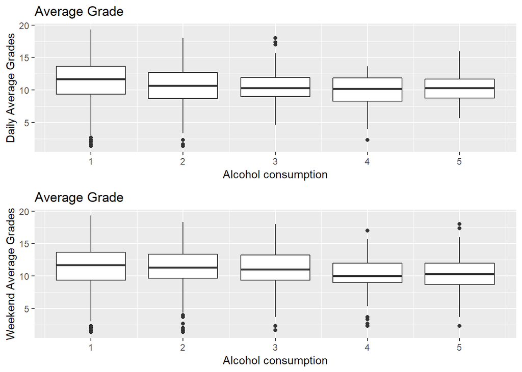

```r
str3=ggplot(apply.source, aes(x=Dalc, y=avggrades, group=Dalc)) +
  geom_boxplot() + theme(legend.position="none") + scale_fill_manual(values=waffle.col) +
  xlab("Alcohol consumption") + ylab("Daily Average Grades") + ggtitle("Average Grade")
str4=ggplot(apply.source, aes(x=Walc, y=avggrades, group=Walc)) +
  geom_boxplot() + theme(legend.position="none") + scale_fill_manual(values=waffle.col) +
  xlab("Alcohol consumption") + ylab("Weekend Average Grades") + ggtitle("Average Grade")
grid.arrange(str3,str4,nrow=2)
```

#### **Thus, levels of alcohol consumption have a limited predict power over their grades.**

## **Part II Purpose**

1. Examine which variable has the most predicative power over student grades.
2. Build model to predict the grades.

#### **Preparation**

- Since failure times is another aspect of grades, it would be meaningless to run T-test with it, so I would just drop it from the data.

```r
failureind <- which(names(apply.source)=="failures")
apply.source <- apply.source[,-failureind]
```

#### **Linear Regression Model**

- Use linear model to find the variables having significant impact on grades, which are **studytime, schoolsup(Extra educational support), higher(Wants to take higher education).**

```r
reg2 <- lm(apply.source$avggrades ~ ., data=apply.source[, 1:29])
summary(reg2)
```

```
##
## Call:
## lm(formula = apply.source$avggrades ~ ., data = apply.source[,
##     1:29])
##
## Residuals:
##      Min       1Q   Median       3Q      Max
## -10.8048  -1.5890   0.1455   1.8676   8.4868
##
## Coefficients:
##                    Estimate Std. Error t value Pr(>|t|)
## (Intercept)      10.6017499  1.8139110   5.845 7.04e-09 ***
## schoolMS         -0.3723012  0.2574810  -1.446  0.14854
## sexM             -0.1215773  0.2255528  -0.539  0.59000
## age              -0.1198027  0.0906465  -1.322  0.18661
## addressU          0.2930648  0.2427090   1.207  0.22756
## famsizeLE3        0.4975437  0.2219491   2.242  0.02522 *
## PstatusT          0.0640413  0.3168516   0.202  0.83987
## Medu              0.1848194  0.1396447   1.323  0.18600
## Fedu              0.1642152  0.1234646   1.330  0.18383
## Mjobhealth        0.7195927  0.4873500   1.477  0.14014
## Mjobother         0.0878501  0.2874717   0.306  0.75998
## Mjobservices      0.3595006  0.3392675   1.060  0.28959
## Mjobteacher       0.1089511  0.4567083   0.239  0.81150
## Fjobhealth       -0.2298997  0.6841685  -0.336  0.73693
## Fjobother         0.0004672  0.4281211   0.001  0.99913
## Fjobservices     -0.2993809  0.4493361  -0.666  0.50540
## Fjobteacher       1.1650673  0.6051943   1.925  0.05452 .
## reasonhome        0.2418873  0.2555691   0.946  0.34416
## reasonother       0.3335054  0.3412013   0.977  0.32861
## reasonreputation  0.4954622  0.2654763   1.866  0.06232 .
## guardianmother   -0.1771667  0.2439794  -0.726  0.46793
## guardianother    -0.2497580  0.4596099  -0.543  0.58698
## traveltime       -0.1100901  0.1449817  -0.759  0.44785
## studytime         0.5080568  0.1272501   3.993 7.06e-05 ***
## schoolsupyes     -1.5979812  0.3190187  -5.009 6.56e-07 ***
## famsupyes        -0.3691163  0.2091140  -1.765  0.07787 .
## paidyes          -0.6938560  0.2413583  -2.875  0.00414 **
## activitiesyes     0.0980887  0.2022346   0.485  0.62777
## nurseryyes        0.0309093  0.2473158   0.125  0.90057
## higheryes         1.9236766  0.3618564   5.316 1.33e-07 ***
## internetyes       0.4269133  0.2569866   1.661  0.09701 .
## romanticyes      -0.4996783  0.2097075  -2.383  0.01739 *
## famrel            0.1569738  0.1056496   1.486  0.13768
## freetime         -0.0399315  0.1029791  -0.388  0.69828
## goout            -0.2127131  0.0995379  -2.137  0.03286 *
## Dalc             -0.1303141  0.1389503  -0.938  0.34857
## Walc             -0.0210543  0.1092166  -0.193  0.84718
## health           -0.1562929  0.0709717  -2.202  0.02790 *
## absences         -0.0181346  0.0162657  -1.115  0.26519
## ---
## Signif. codes:  0 '***' 0.001 '**' 0.01 '*' 0.05 '.' 0.1 ' ' 1
##
## Residual standard error: 2.943 on 920 degrees of freedom
## Multiple R-squared:  0.2015, Adjusted R-squared:  0.1685
## F-statistic:  6.11 on 38 and 920 DF,  p-value: < 2.2e-16
```

#### **ANOVA**

- Now I would like to check the three variables found above is more important in this model.
- In other words, if I have to remove one variable within them, which would impact the result the most.
- As the result, we can tell that **aiming to having higher education or not** is the most important variable.

```r
m1 <- lm(apply.source$avggrades ~ studytime, data=apply.source)
m2 <- lm(apply.source$avggrades ~ higher, data=apply.source)
m3 <- lm(apply.source$avggrades ~ schoolsup, data=apply.source)
m4 <- update(m3, . ~ . + studytime + higher,  data = apply.source)
res_lm <- lapply(list(m1, m2, m3, m4), summary)
(res_lm[[4]]$r.sq - res_lm[[1]]$r.sq)/res_lm[[4]]$r.sq
```

```
## [1] 0.6928621
```

```r
anova(m1, m4)
```

```
## Analysis of Variance Table
##
## Model 1: apply.source$avggrades ~ studytime
## Model 2: apply.source$avggrades ~ schoolsup + studytime + higher
##   Res.Df    RSS Df Sum of Sq      F    Pr(>F)
## 1    957 9665.4
## 2    955 8957.8  2    707.52 37.715 < 2.2e-16 ***
## ---
## Signif. codes:  0 '***' 0.001 '**' 0.01 '*' 0.05 '.' 0.1 ' ' 1
```

```r
(res_lm[[4]]$r.sq - res_lm[[2]]$r.sq)/res_lm[[4]]$r.sq
```

```
## [1] 0.3354754
```

```r
anova(m2, m4)
```

```
## Analysis of Variance Table
##
## Model 1: apply.source$avggrades ~ higher
## Model 2: apply.source$avggrades ~ schoolsup + studytime + higher
##   Res.Df    RSS Df Sum of Sq      F    Pr(>F)
## 1    957 9300.4
## 2    955 8957.8  2    342.57 18.261 1.649e-08 ***
## ---
## Signif. codes:  0 '***' 0.001 '**' 0.01 '*' 0.05 '.' 0.1 ' ' 1
```

```r
(res_lm[[4]]$r.sq - res_lm[[3]]$r.sq)/res_lm[[4]]$r.sq
```

```
## [1] 0.899379
```

```r
anova(m3, m4)
```

```
## Analysis of Variance Table
##
## Model 1: apply.source$avggrades ~ schoolsup
## Model 2: apply.source$avggrades ~ schoolsup + studytime + higher
##   Res.Df    RSS Df Sum of Sq      F    Pr(>F)
## 1    957 9876.2
## 2    955 8957.8  2    918.41 48.956 < 2.2e-16 ***
## ---
## Signif. codes:  0 '***' 0.001 '**' 0.01 '*' 0.05 '.' 0.1 ' ' 1
```

#### **Regression Tree Model**

- We use the regression tree to determine the variables in the new model.
- According the regression tree below, we found:
1. The overwhelming majority of surveyed students would like to **pursue higher education** and their average grades (11.4/20) is significantly higher than the average grades of those who don’t (8.47/20).
2. **Mother’s education** is another important feature (interestingly, this feature **did not come up as important** in the linear regression model) if you aim to pursue higher education.
3. Extra educational support also have great impact on student’s grades if you aim to pursue higher education and your mother have higher education levels. Student **without extra educational support have higher average grades** (12.5/20) than those who do (9.78/20). It’s kinda **out of universal expetaction**.

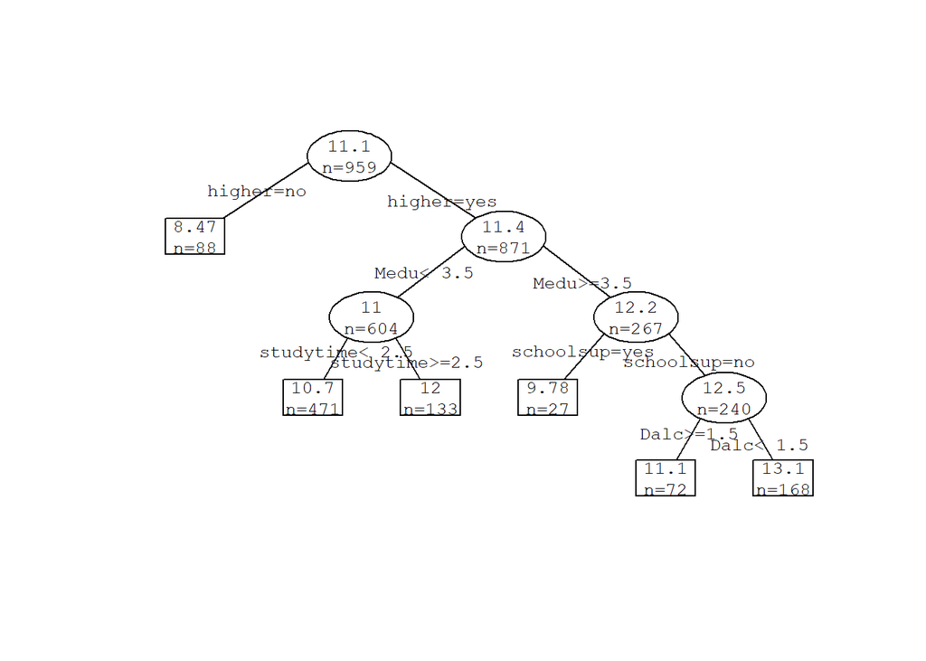

```r
library(rpart)
library(DMwR)
regtree <- rpart(apply.source$avggrades~., data=apply.source[,1:29])
prettyTree(regtree)
```

#### **Normalized Mean Squared Error(NMSE)**

- Before getting into cross-validation, I want to have a simple look at the validation of these two model, so I choose to calculate their NMSE to see which one works better.
- The NMSE of these two model is high, which may indicate that **the results would not be quite valid** at all, but it seems like **linear regression works better** than the regression tree.

```r
#predictions
apply.source$Dalc <- as.numeric(apply.source$Dalc)
lm.predictions <- predict(reg2,apply.source)
rt.predictions <- predict(regtree,apply.source)
nmse.lm<-mean((lm.predictions-apply.source[,"avggrades"])^2)/mean(
  (mean(apply.source$avggrades)-apply.source[,"avggrades"])^2)
nmse.rt<-mean((rt.predictions-apply.source[,"avggrades"])^2)/mean(
  (mean(apply.source$avggrades)-apply.source[,"avggrades"])^2)
print(nmse.lm) #0.79
```

```
## [1] 0.7984877
```

```r
print(nmse.rt) #0.85
```

```
## [1] 0.849412
```

#### **Plot**

- Now let’s see the error scatter plot which the two model predicted.
- Unfortunately, as the NMSEs and error plots indicate, neither of the two models seems to do a decent job in predicting student average grades.

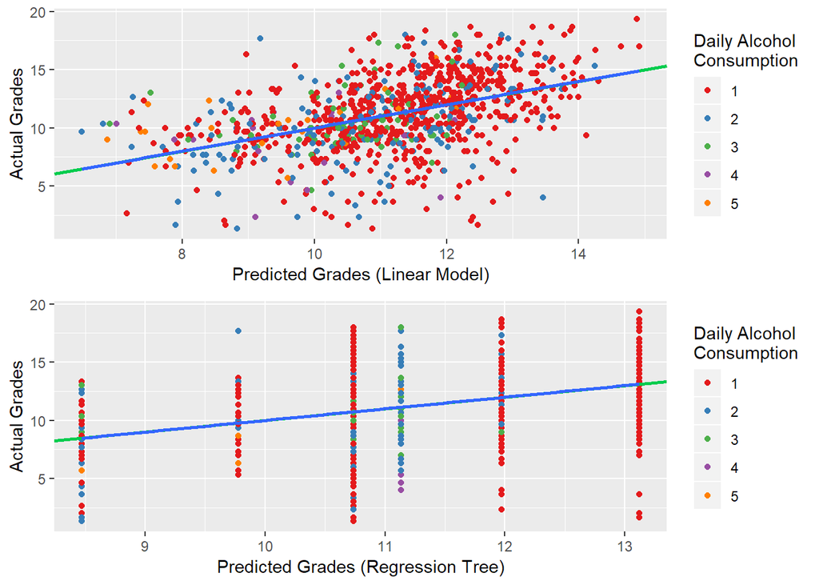

```r
lm.plt.data1=data.frame(cbind(lm.predictions,apply.source[,"avggrades"]))
colnames(lm.plt.data1) <- c("lm.predictions","avggrades")
rt.plt.data1=data.frame(cbind(rt.predictions,apply.source[,"avggrades"]))
colnames(rt.plt.data1) <- c("rt.predictions","avggrades")

apply.source$Dalc <- as.factor(apply.source$Dalc)

errplt.lm1 <- ggplot(lm.plt.data1,aes(lm.predictions,avggrades))+
  geom_point(aes(color=apply.source[,"Dalc"]))+
  xlab("Predicted Grades (Linear Model)")+
  ylab("Actual Grades")+
  geom_abline(intercept=0,slope=1,color="#00cc4e",size=1)+
  geom_smooth(method = "lm", se = FALSE)+
  scale_colour_brewer(palette = "Set1",name = "Daily Alcohol \nConsumption")

errplt.rt1 <- ggplot(rt.plt.data1,aes(rt.predictions,avggrades))+
  geom_point(aes(color=apply.source[,"Dalc"]))+
  xlab("Predicted Grades (Regression Tree)")+
  ylab("Actual Grades")+
  geom_abline(intercept=0,slope=1,color="#00cc4e",size=1)+
  geom_smooth(method = "lm", se = FALSE)+
  scale_colour_brewer(palette = "Set1",name = "Daily Alcohol \nConsumption")

grid.arrange(errplt.lm1,errplt.rt1,nrow=2)
```

#### **Random Forest Model**

- Since the two model above do not work well, I would insteadly use **random forest** model to make another attempt.
- Set the seed in oreder to get the same result every time.
- Use random forest with 500 trees to predict the grades.
- Calculate the NMSE of this model, and then get the result of about 0.2, which indicate that **this model is more valid** than the ones above.

```r
library(randomForest)
set.seed(8000)
rf2 <- randomForest(apply.source$avggrades~., data=apply.source[,1:29], ntree=500, importance=T)
rf.predictions <- predict(rf2,apply.source)
nmse.rf <- mean((rf.predictions-apply.source[,"avggrades"])^2)/mean(
  (mean(apply.source$avggrades)-apply.source[,"avggrades"])^2)
print(nmse.rf) #0.2
```

```
## [1] 0.2037917
```

#### **Plot**

> *The out-of-bag (oob) error estimate: In random forests, there is no need for cross-validation or a separate test set to get an unbiased estimate of the test set error. It is estimated internally , during the run…*

it seems like due to the build-in algorithms that I don’t really know, **it’s not necessary to run a cross validation** to ensure the stablity of the random forest model, HURRAY!

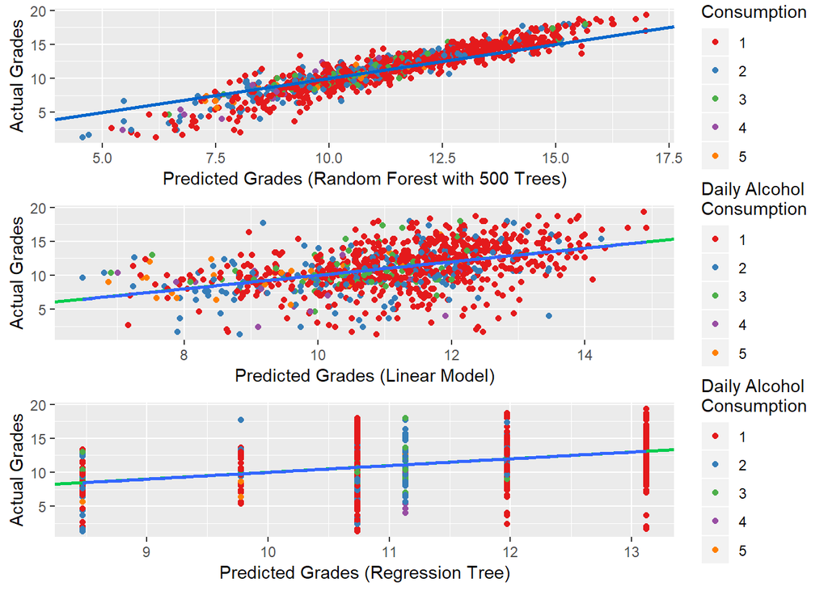

```r
#first combine the rf predictions and actual scores in a single data frame
rf.plt.data1 <- data.frame(cbind(rf.predictions,apply.source[,"avggrades"]))
colnames(rf.plt.data1)<-c("rf.predictions","avggrades")

# then create the error plot.
errplt.rf1 <- ggplot(rf.plt.data1,aes(rf.predictions,avggrades))+
  geom_point(aes(color=apply.source[,"Dalc"]))+
  xlab("Predicted Grades (Random Forest with 500 Trees)")+
  ylab("Actual Grades")+
  geom_abline(intercept=0,slope=1,color="#0066CC",size=1)+
  #geom_smooth(method = "lm", se = FALSE)+
  scale_colour_brewer(palette = "Set1",name = "Daily Alcohol \nConsumption")
#finally, plot the error plot from the random forest with the error plots of the linear and regression tree models.
grid.arrange(errplt.rf1, errplt.lm1,errplt.rt1,nrow=3)
```

#### **Relative Importance in Random Forest Model**

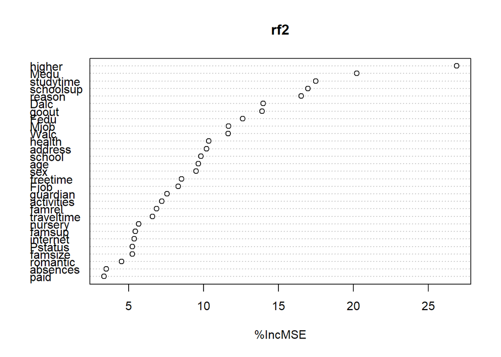

```r
varImpPlot(rf2,type=1)
```

#### **Partial Dependance**

- Now I am going to produce a partial dependence plot for each feature in the best performing Random Forest model with 500 trees., giving a graphical depiction of **the marginal effect** of a feature on the response.

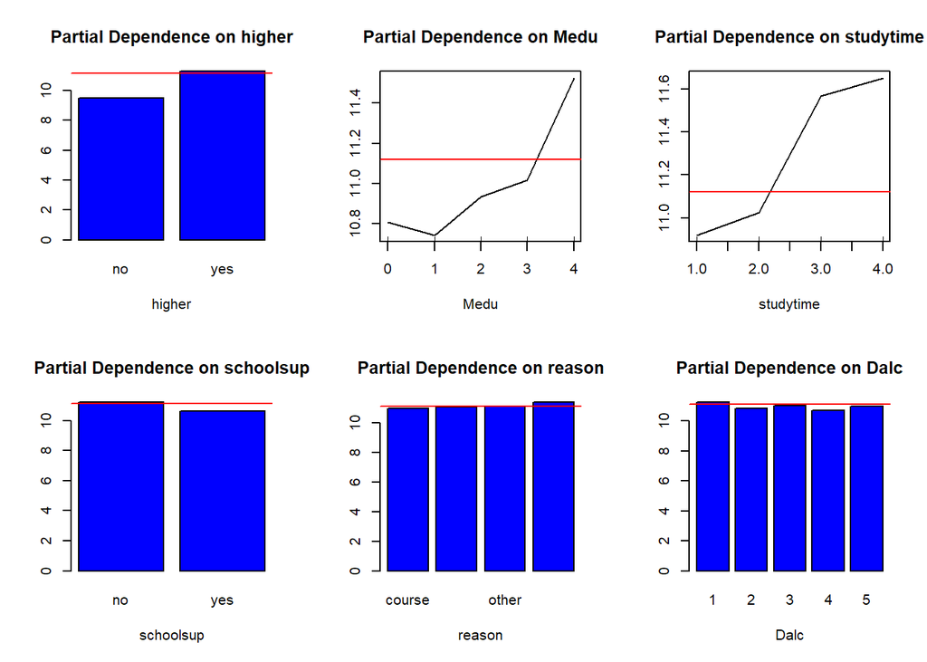

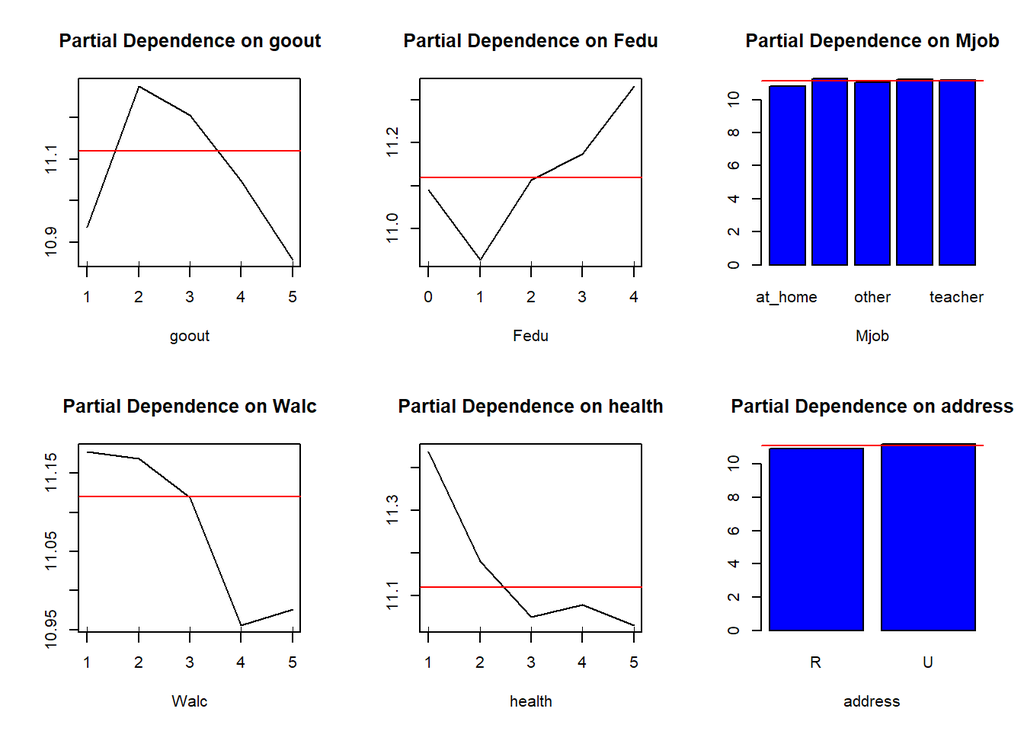

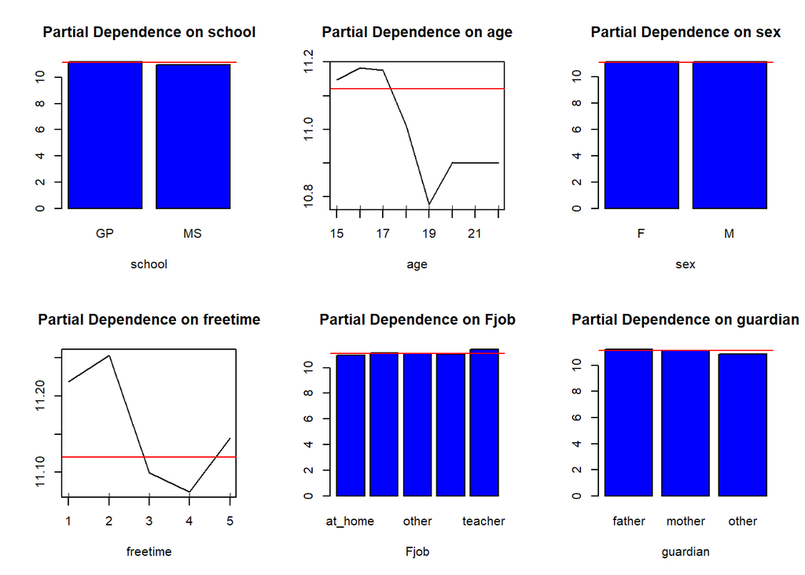

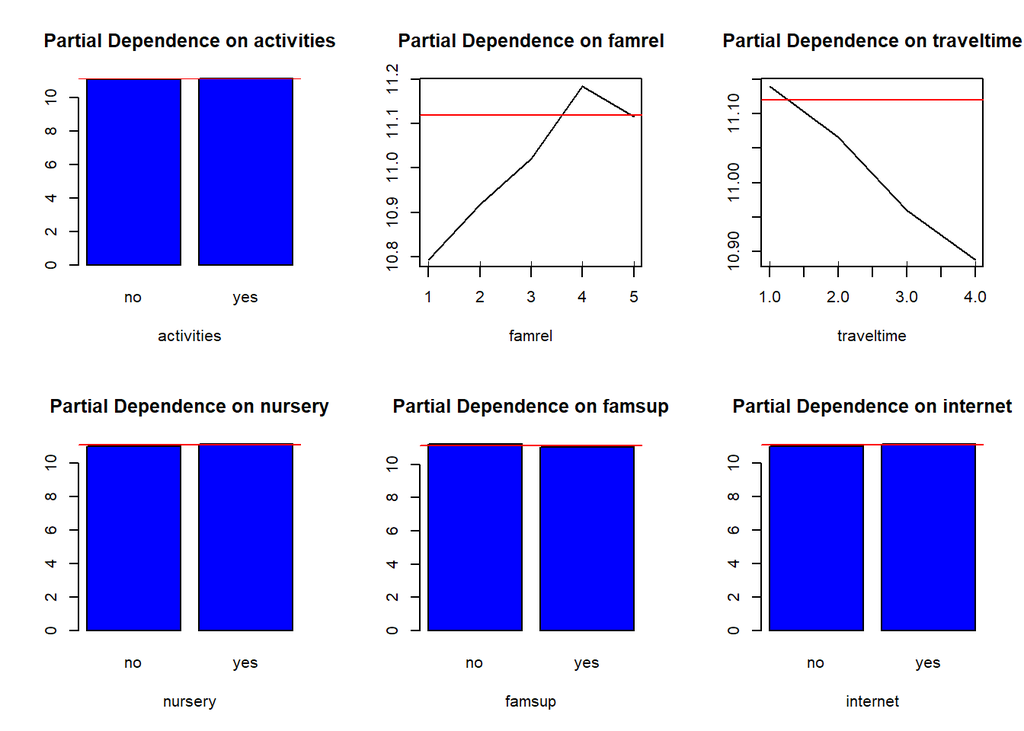

```r
imp <- importance(rf2)
impvar <- rownames(imp)[order(imp[, 1], decreasing=TRUE)]
op <- par(mfrow=c(2, 3))
for (i in seq_along(impvar)) {
  partialPlot(rf2, apply.source[,1:29], impvar[i], rug=TRUE, xlab=impvar[i],
              main=paste("Partial Dependence on", impvar[i]))
  abline(h=mean(apply.source$avggrades),col="red")
}
```

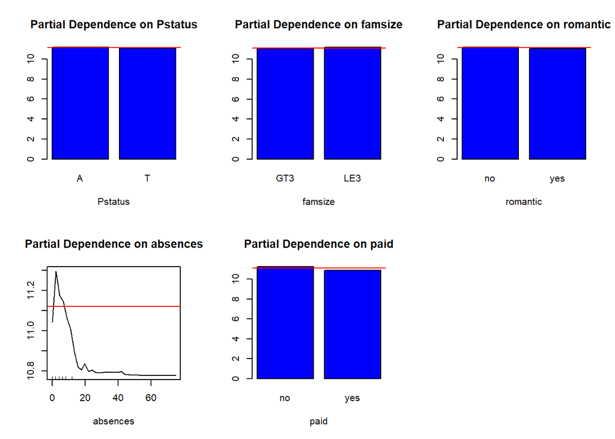

```r
par(op)
```

#### **Correlation Plot**

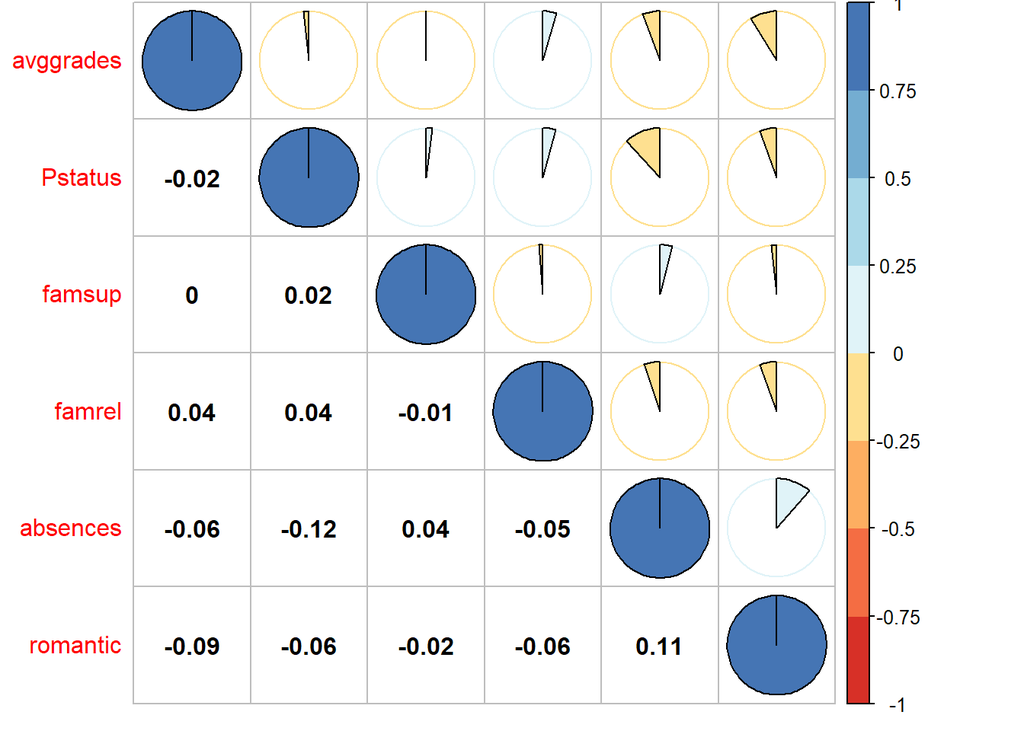

```r
imp.var <- apply.source[,c('avggrades','Pstatus','famsup','famrel','absences', 'romantic')]
imp.var$Pstatus <- as.numeric(as.factor(imp.var$Pstatus)) -1
# 0 represent A which indicate apart while 1 represent T which indicate together
imp.var$famsup <- as.numeric(as.factor(imp.var$famsup)) -1
# 0 represent no while 1 represent yes
imp.var$romantic <- as.numeric(as.factor(imp.var$romantic)) -1
# 0 represent no while 1 represent yes

library(RColorBrewer)
require(corrplot)
corrplot(cor(imp.var), method="pie", addrect = 4, type = 'upper',
         tl.pos = 'tp', col=brewer.pal(n=8, name="RdYlBu"))
corrplot(cor(imp.var), add = TRUE, type = 'lower', method = 'number',
         col = 'black', diag = FALSE, tl.pos = 'n', cl.pos = 'n')
```

## **Conclusion**

##### **Statistic is funny though exhausting LOL**.